# Plotly, ggplot2, and R

[Plotly](http://www.plot.ly) is a cool, open-source project ( [github](https://github.com/plotly) ) to help people get interactive plots online easily through a number of various programming languages. This page serves as a guide to using it with [R's](http://www.r-project.org/) [ggplot2](http://ggplot2.org/) visualization and plotting package and will be updated as support for new geoms (ggplot plots/visualization types) are added.

Most examples will be taken straight from [ggplot's docs website](http://docs.ggplot2.org/current/). The master list of geoms is at the botttom of this post. Some of the plots have minor errors.

## Installing Plot.ly

Installing Plot.ly within R is easy.

```r
# autoloads ggplot
library(devtools)
install_github("plotly", "ropensci")
signup("yourusername", "youremail@foo.bar")
```

```r
library(plotly)
py <- plotly(username = "xysmas", key = plotly.key)
```

# On With the Plots

## geom_abline, hline, vline

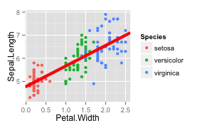

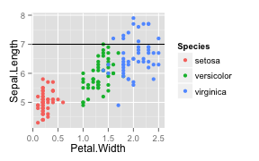

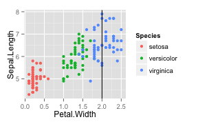

```r
coefs <- coef(lm(Sepal.Length ~ Petal.Width, data = iris))
p.iris <- ggplot(iris, aes(Petal.Width, Sepal.Length, color = Species))
p.iris <- p.iris + geom_point()
p.iris.hline <- p.iris + geom_hline(yintercept = 7)
p.iris.abline <- p.iris + geom_abline(intercept = coefs[1], slope = coefs[2],
    colour = "red", size = 2)
p.iris.vline <- p.iris + geom_vline(xintercept = 2)
p.iris.abline
p.iris.hline
p.iris.vline
```

```r
py$ggplotly(p.iris.abline)
```

```
## Error: conversion not implemented for geom_abline (basic geom_abline)
```

```r
# odd little error
py$ggplotly(p.iris.hline)
```

```
## Error: object 'Petal.Width' not found
```

```r
# odd little error
py$ggplotly(p.iris.vline)
```

```
## Error: object 'Petal.Width' not found
```

geom_abline doesn't work.

## geom_jitter

```r
p <- ggplot(iris, aes(Petal.Width, Sepal.Length, color = Species))
p + geom_jitter()
py$ggplotly(p + geom_jitter())
```

```
## Error: conversion not implemented for geom_jitter (basic geom_jitter)
```

```r
# try position instead
py$ggplotly(p + geom_point(position = position_jitter()))
```

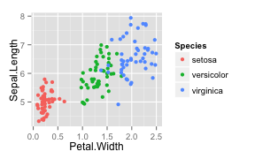

[interactive chart not shown]

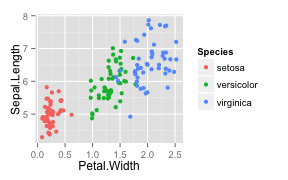

[interactive chart not shown]

geom_jitter fails, but position jitter passed to geompoint seems to work fine.

## geom_line

(potentially the most useless plot ever, but just as an example…)

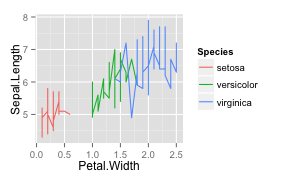

[interactive chart not shown]

```r
p <- p + geom_line()
p
```

```r
py$ggplotly(p)
```

[interactive chart not shown]

yes, funny that abline and the other line geoms do not work.

## geom_path

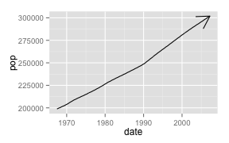

[interactive chart not shown]

```r
# Use the arrow parameter to add an arrow to the line See ?grid::arrow for
# more details
library(grid)
c <- ggplot(economics, aes(x = date, y = pop))
# Arrow defaults to 'last'
c + geom_path(arrow = arrow())
py$ggplotly(c + geom_path(arrow = arrow()))
```

## geom_point

Clearly this works.

## geom_polygon

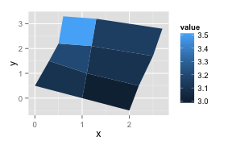

[interactive chart not shown]

```r
### example straight from ggplot2 When using geom_polygon, you will typically
### need two data frames: one contains the coordinates of each polygon
### (positions), and the other the values associated with each polygon
### (values).  An id variable links the two together

ids <- factor(c("1.1", "2.1", "1.2", "2.2", "1.3", "2.3"))

values <- data.frame(id = ids, value = c(3, 3.1, 3.1, 3.2, 3.15, 3.5))

positions <- data.frame(id = rep(ids, each = 4), x = c(2, 1, 1.1, 2.2, 1, 0,
    0.3, 1.1, 2.2, 1.1, 1.2, 2.5, 1.1, 0.3, 0.5, 1.2, 2.5, 1.2, 1.3, 2.7, 1.2,
    0.5, 0.6, 1.3), y = c(-0.5, 0, 1, 0.5, 0, 0.5, 1.5, 1, 0.5, 1, 2.1, 1.7,
    1, 1.5, 2.2, 2.1, 1.7, 2.1, 3.2, 2.8, 2.1, 2.2, 3.3, 3.2))

# Currently we need to manually merge the two together
datapoly <- merge(values, positions, by = c("id"))

(p <- ggplot(datapoly, aes(x = x, y = y)) + geom_polygon(aes(fill = value, group = id)))
py$ggplotly(p)
rm(p)
```

## geom_ribbon

[output not shown]

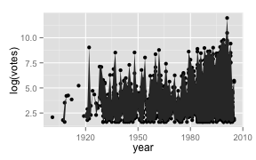

[interactive chart not shown]

```r
msamp <- movies[sample(nrow(movies), 1000), ]
m <- ggplot(msamp, aes(y = log(votes), x = year))
m <- m + geom_point()
m <- m + stat_summary(geom = "ribbon", fun.ymin = "min", fun.ymax = "max")
m
py$ggplotly(m)
```

Points work, stat summary doesn't.

## geom_segment

example from ggplot docs

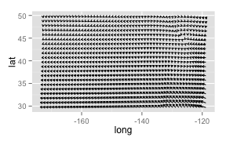

[interactive chart not shown]

```r
library(grid)  # needed for arrow function
p <- ggplot(seals, aes(x = long, y = lat))
p <- p + geom_segment(aes(xend = long + delta_long, yend = lat + delta_lat),
    arrow = arrow(length = unit(0.1, "cm")))
p
py$ggplotly(p)
```

# master list of geoms:

[ggplot2 docs](http://docs.ggplot2.org/current/)

### geoms

- geom_abline() = FALSE
- geom_area() = FALSE
- geom_bar() = FALSE
- geom_bin2d() = FALSE
- geom_blank() =
- geom_boxplot() = FALSE
- geom_contour() = FALSE
- geom_crossbar() = FALSE
- geom_density() = FALSE
- geom_density2d() = FALSE
- geom_dotplot() = FALSE
- geom_errorbar() = FALSE
- geom_errorbarh() = FALSE
- geom_freqpoly() = FALSE
- geom_hex() = Untested
- geom_histogram() = FALSE
- geom_hline() = FALSE
- geom_jitter() = FALSE
- geom_line() = TRUE
- geom_linerange() = FALSE
- geom_map() = FALSE
- geom_path() = TRUE
- geom_point() = TRUE
- geom_pointrange() = FALSE
- geom_polygon() =TRUE
- geom_quantile() = FALSE
- geom_raster() = FALSE
- geom_rect() = FALSE
- geom_ribbon() = FALSE
- geom_rug() = FALSE
- geom_segment() = TRUE
- geom_smooth() = FALSE
- geom_step() = FALSE
- geom_text() = FALSE
- geom_tile() = FALSE
- geom_violin() = FALSE
- geom_vline() = FALSE

### stats

- stat_abline() = FALSE
- stat_bin()
- stat_bin2d()
- stat_bindot()
- stat_bindot()
- stat_binhex()
- stat_contour()
- stat_density()
- stat_density2d()
- stat_ecdf()
- stat_function()
- stat_hline()
- stat_identity()
- stat_qq()
- stat_quantile() = false
- stat_smooth()
- stat_spoke()
- stat_sum()
- stat_summary()
- stat_summary_hex()
- stat_summary2d()
- stat_unique()
- stat_vline()
- stat_ydensity()

### other ggplot stuff

- expand_limits
- guide_legend
- guide_colourbar(guide_colorbar)
- scale_alpha(scale_alpha_continuous, scale_alpha_discrete)
- scale_area()
- scale_color_brewer
- scale_color_continuous
- scale_color_discrete
- scale_color_gradient
- scale_color_gradient2
- scale_color_gradientn
- coord_cartesian
- coord_equal
- coord_fixed
- coord_flip
- coord_map = FALSE
- coord_polar
- coord_trans
- facet_grid
- facet_null
- facet_wrap
- position_dodge
- position_fill
- position_identity
- position_jitter
- position_stack